# Final Project: Progress Report

Nov 9, 2020

# Overview

> In this progress report, you’ll show some intermediate results of your final project. (Note: This milestone is considered as part of the project management. The grades are only tentative. You should focus on getting some progress. Your final project outcome will outweight the intermediate results.) 0. (5%) Fill the basic information

[output not shown]

1. (40%) Extend your abstract, describe your project in more details. It should be 300–500 words in length providing:
   - your project goal, or the problem you plan to work on;
   - (motivation and significance) why the problem is interesting and/or important;
   - the approach you plan to take, including what data mining tasks you will perform, and what potential techniques you will try;
   - what dataset you plan to use and how you will get the data (if the data is publicly available, provide the exact reference to the data; otherwise, provide a description about the data source).
2. (30%) Give some preliminary description or analysis about your dataset(s). You should have early numbers or a figure in this report. This part can be short or long, depending on your actual progress.
3. (25%) The following questions are design to help you manage the progress in doing the final project. Your answers don’t need to be long or detailed but will show that you have a plan to address them in your final report.
   1. What do you try to accomplish in this project? What have you done so far?
   2. What are the strengths/novelty of your proposed idea? Why is the problem challenging?
   3. How will you evaluate your method(s)? What are the performance measures and baseline methods?
   4. Have you found any the research or works related to your project/problem/data? Where do you find the related work?
   5. Are there any challenges you encounter so far? How do you plan to solve it?

# 0. Fill the basic information

- Project title: {Decide people’s political leanings based on their tweet posts}
- Repository: {https://github.com/class-data-mining-master/2020-fall-dm-project-team12-election}
- Team member(s): Xu, Xuezhi (email: XUX15@pitt.edu) Liu, Xinming (email: XIL231@pitt.edu) Li, Jingyang (email: JIL281@pitt.edu)

# 1. Extended abstract

(By Xinming Liu)

1. Our group will be working on Topic 2, which is predicting the political leanings of Twitter users by their tweets during the 2016 US presidential election debates.
2. Polls generally play an important role in US presidential elections, where not only people get a sense of the potential outcomes of the election, but also help the election teams and related organizations further plan their rallies. However, polls from recent years have shown less predictive power according to the final election results. We recognize social networks, particularly Twitter, is a low-cost platform for people to express their political leanings where much more data could potentially collected and analyzed compared to traditional polls. By mining the tweet text data during the 2016 US presidential election debates, we seek to predict either which party they voted for (Democrat or Republican, Dataset A) or which candidate they followed on Twitter (Clinton or Trump, Dataset B) by their tweets during the debates. We will focus on state-wise results to see which states are potentially more important for the candidate before the election and compare with their road maps back in 2016.
3. The general approach should be keyword extraction as the key information to predict political leanings is the tweet contents. Text data usually needs a series of pre-processing including tokenization, normalization, stop word removal, etc. A more important task should be recognizing the key words with predictive power which we will look for in the processed tweets, this include the names (e.g. Mike Pence), account IDs of people (e.g. @realDonaldTrump) and organizations (e.g. @TeamTrump) from the two parties, important hashtagged topics (e.g. #VPdebate) and more. With all those keywords extracted and user’s affiliation, we will be able to start our supervised learning task to build, train, test and evaluate different classification models. Since the data is not unbiased across all US states, the attribute we would focus on is the predictive power of tweets on different states. Finally, valuable findings will be visualized.
4. We will use the provided dataset: http://www.yurulin.com/class/spring2017_datamining/data/twitter_debate2016/ SetA: 22K users whose party aﬃliation were identiﬁed through their vote registration. SetB: 831K users whose supporting candidates (Clinton or Trump) were identiﬁed from their following information.

# 2. Preliminary results

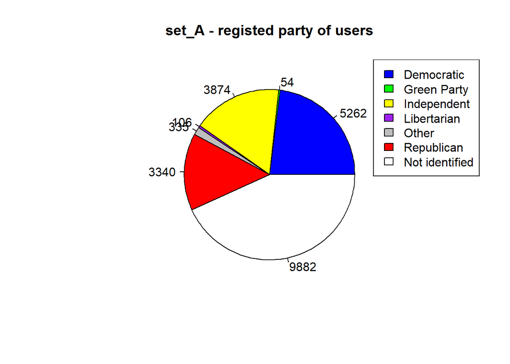

```r
A_user = read.csv("user_setA/users.csv")
B_user = read.csv("user_setB/users.csv")

A_party = table(A_user$party, useNA = "always")

pie(A_party, labels = A_party, col = c("blue", "green", "yellow", "purple", "grey", "red", "white"), main = "set_A - registed party of users")
legend("topright", c("Democratic", "Green Party", "Independent", "Libertarian", "Other", "Republican", "Not identified"), fill = c("blue", "green", "yellow", "purple", "grey", "red", "white"))
```

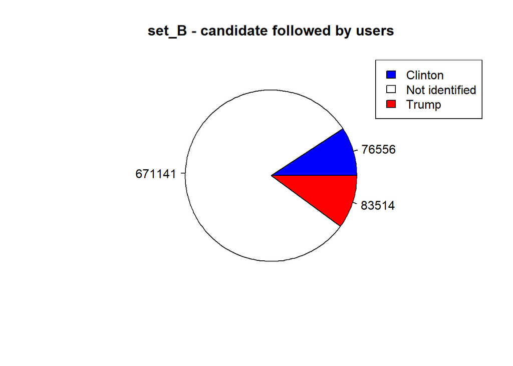

```r
B_party = table(B_user$follow_candidate)

pie(B_party, labels = B_party, col = c("blue", "white", "red"), main = "set_B - candidate followed by users")
legend("topright", c("Clinton", "Not identified", "Trump"), fill = c("blue", "white", "red"))
```

The second dataset is very large but only a small part can be used for training.

# 3. Your answers to Problem 3.

(By Jingyang Li)

1. We want to try to predict the election results of the people’s political faction based on the twitter information. We are now try to transfer our data into more regularized and less unrelated variable
2. I think one novelty is that we are not decide people’s faction only based on what political views they saw or they like but what they truely believed. The challending part is that we now can’t find how to find what’s people’s true thoughs. Sometimes people may be shy to confess their political faction.
3. We will use the MSE(mean square error),accuracy and other measure methods. I think the baseline of the accuracy will be 60%,actually once the accuracy is above 50%, I think we can say that it is useful.
4. I have found serveral related project works on github. Like predict people’s music taste, I think they are not much different.

e）Yes, the main challenges we met is how to let the model’s output “know” what’s people really thinking. We will try to find some inspirations from other related works and see if we can solve this problem.